# Proteomics_vs_UTR

> Analysis of 3'UTR usage vs. protein production in neural stem cells of the subventricular zone (Preprint: Goepferich & George et al. 2020)

Final plots in the paper may differ slightly due to:

- figures are not in order as in the paper (due to the intrinsic logic of this script and the input data)
- changes pending on the peer-review process
- collecting and final editing of sub-plots in Adobe Illustrator
- differences R package versions or other parameters

> Note: This is a reporting file providing all the necessary programming code to comprehend the main results of the paper.

> Note: Precompield files are provided in this directory.

> Note: Computed as HTML-File

## Load the data (This will be provided in a table)

These are the proteomics (quantified protein expression) and transcriptomics results (gene expression levels)

```r
load(file = 'proteomics_data.rda')

te_tbl
```

| ENSG | TE_BMP | TE_EGF | EGFR_LFQ | EGFR_BM | BMP4_LFQ | BMP4_BM | Prot_Sig | Prot_FC | mRNA_log_FC | Prot_Pvalue |
| --- | --- | --- | --- | --- | --- | --- | --- | --- | --- | --- |
| ENSMUSG00000000168 | 0.6818373538 | 0.8763635509 | 29009.26 | 875.05227 | 28919.62 | 971.94612 | NA | -0.0896383921 | 0.1515071306 | 0.302502350 |
| ENSMUSG00000000278 | 0.7493336668 | 1.0959382302 | 26525.31 | 687.16226 | 26957.95 | 864.60562 | NA | 0.4326407115 | 0.3313914097 | 0.090213895 |
| ENSMUSG00000000339 | 0.9456632577 | 0.0095878145 | 25783.09 | 1418.26654 | 26422.79 | 739.62012 | NA | 0.6396999359 | -0.9392723244 | 0.467046406 |
| ENSMUSG00000000340 | 0.5803714983 | 2.1068291337 | 26343.24 | 338.65659 | 27771.16 | 1001.35447 | BMP4 | 1.4279174805 | 1.5640577722 | 0.000000000 |
| ENSMUSG00000000384 | 2.6323220510 | 1.0403474234 | 25944.76 | 698.52658 | 25703.31 | 223.50349 | NA | -0.2414410909 | -1.6440176216 | 0.806771822 |
| ENSMUSG00000000538 | 0.3119876517 | 2.2228882542 | 24653.93 | 292.44171 | 25630.15 | 1113.10622 | NA | 0.9762163162 | 1.9283702581 | 0.082502463 |
| ENSMUSG00000000552 | -0.0591667321 | 1.0784429686 | 24529.82 | 643.22024 | 23847.62 | 1339.55055 | BMP4 | -0.6822020213 | 1.0583643056 | 0.042292398 |
| ENSMUSG00000000561 | 1.1030125409 | 0.4490781773 | 27792.77 | 1127.34007 | 27182.88 | 682.27382 | BMP4 | -0.6098842621 | -0.7245000106 | 0.017631236 |
| ENSMUSG00000000563 | -2.5734928767 | -2.6003880818 | 30652.91 | 10293.79674 | 31019.00 | 9954.72799 | BMP4 | 0.3660920461 | -0.0483214009 | 0.012050633 |
| ENSMUSG00000000568 | -0.2817339571 | -1.0893533805 | 31307.95 | 3688.85673 | 31252.04 | 2048.29189 | NA | -0.0559094747 | -0.8487524373 | 0.890233710 |

[output cut: 2259 more lines]

> TE = translation efficiency or translation index (protein by mRNA)

> LFQ = label free quantification (protein quantification)

> BM = base mean (convention, summed UMI counts over single cells)

> EGF/EGFR = EGF treated in *in-vitro* NSCs (this represent *in-vivo* active NSCs)

> BMP/BMP4 = BMP4 treated in *in-vitro* NSCs (this represent *in-vivo* quiescent NSCs)

## Inspect the proteomics results (as a volcano plot)

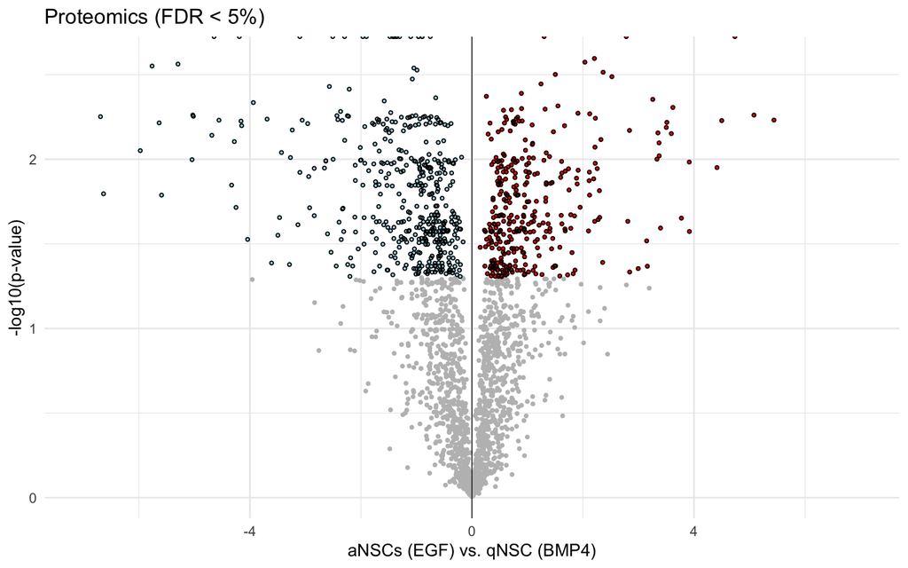

```r
# subset proteins to non-significant
te_ns   <- filter(te_tbl, is.na(Prot_Sig) )
# ... and significant ones
te_sg_a <- filter(te_tbl, !is.na(Prot_Sig) & Prot_FC < 0)
te_sg_q <- filter(te_tbl, !is.na(Prot_Sig) & Prot_FC > 0)

                        # flip LFC direction
ggplot( te_ns, aes( x = (-1)*Prot_FC, y = -log10(Prot_Pvalue) ) ) +
  geom_point(col = 'grey', size = .75) +
  geom_point(data = te_sg_q, col = 'lightblue', size = .75) +
  geom_point(data = te_sg_q, col = 'black', shape = 1, size = .75) +
  geom_point(data = te_sg_a, col = 'red', size = .75) +
  geom_point(data = te_sg_a,col = 'black', shape = 1, size = .75) +
  geom_vline(xintercept = 0, col = 'black', size = .25) +
  theme_minimal() +
  xlim(c(-7., 7.)) +
  labs(x = "aNSCs (EGF) vs. qNSC (BMP4)",
       y = '-log10(p-value)') +
  ggtitle('Proteomics (FDR < 5%)')
```

> ... continue with the comparison of proteomics to 3'UTR trends

## Effect of 3'UTR shortening on protein production (protein intensities by gene counts) comparing *in-vitro* active to quiescent NSCs

> ... first as a boxplot (to see the group difference)

> Note: Here we focus on the significant proteins (since they have less noice than others).

```r
# subset to the shortening genes (3'UTR shortening from in vitro)
shorter_vit <- which(vitro_corr < -.1 & p.adjust(vitro_test, method = 'fdr') < .05 )

# subset to significant genes
te_sht  <- filter(te_tbl, ENSG %in% substring( names(shorter_vit), 1, 18 ) & Prot_Sig == 'BMP4' )
te_ctrl <- filter(te_tbl, Prot_Sig == 'BMP4' & !(ENSG %in% substring( names(shorter_vit), 1, 18 )  ) ) # match

# compute delta in protein production (aNSCs vs. qNSCs)
ctrl    <- te_ctrl$TE_EGF - te_ctrl$TE_BMP
sht     <- te_sht$TE_EGF - te_sht$TE_BMP

# nominal significance (test based on genes/proteins)
wilcox.test(ctrl, sht)
```

```
##
##  Wilcoxon rank sum test with continuity correction
##
## data:  ctrl and sht
## W = 34356, p-value = 0.001977
## alternative hypothesis: true location shift is not equal to 0
```

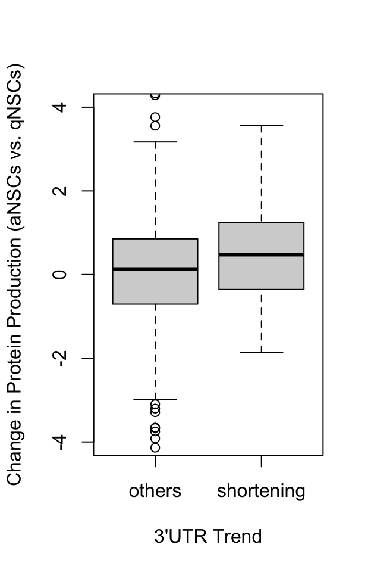

```r
# plot it as a boxplot
boxplot( list(others = ctrl, shortening = sht),
        ylim = c(-4,4), xlab = "3'UTR Trend",
        ylab = 'Change in Protein Production (aNSCs vs. qNSCs)')
```

> ... now as a scatter-plot

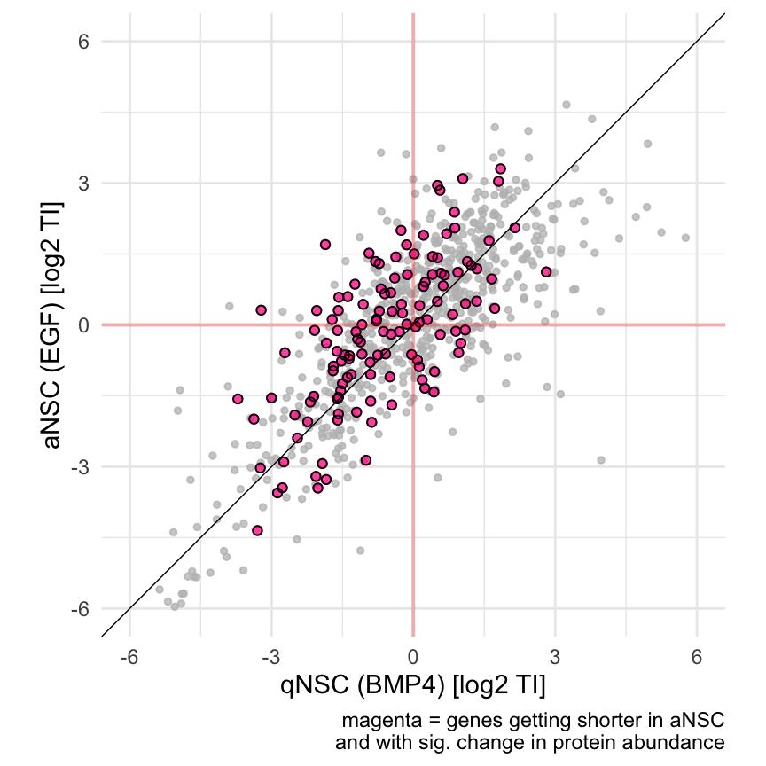

```r
gg_scat_trend <- ggplot( te_ctrl, aes( x = TE_BMP, y = TE_EGF ) ) +
  geom_point(col = 'grey', size = 1, alpha = .75) +
  geom_point(data = te_sht, col = 'deeppink', alpha = .75, size = 1.5) +
  geom_point(data = te_sht, col = 'black', shape = 1, size = 1.5) +
  geom_hline(yintercept = 0, size = .75, alpha = .25, col = 'red') +
  geom_vline(xintercept = 0, size = .75, alpha = .25, col = 'red') +
  geom_abline(slope = 1, intercept = 0, col = 'black', size = .25) +
  theme_minimal() +
  ylim(c(-6,6)) + xlim(c(-6,6)) +
  coord_equal() +
  labs(x = "qNSC (BMP4) [log2 TI]",
       y = 'aNSC (EGF) [log2 TI]',
       caption = 'magenta = genes getting shorter in aNSC\nand with sig. change in protein abundance'
       ) +
  theme(plot.title = element_text(color = 'deeppink', size = 10))

gg_scat_trend
```

> ... next, the analysis will center around the triplicates from proteomics to estimate biological variation

> ... an interaction test (linear model) applied on a averaged gene/protein effect (for 3'UTR shortening genes) will be carried out over the triplicates

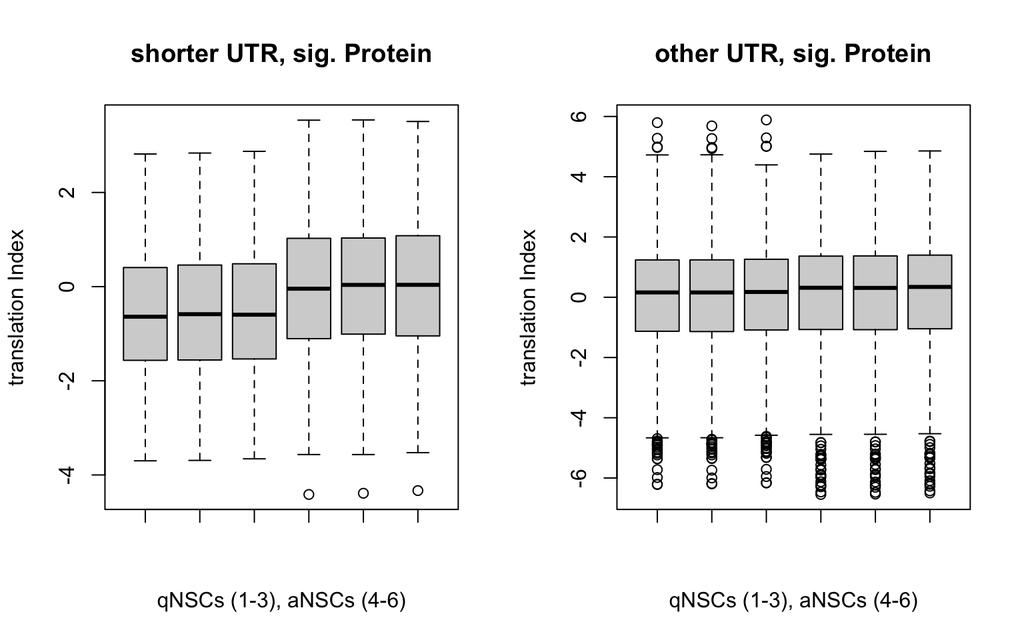

```r
mt <- match(te_tbl$ENSG, prot_nms$ENSG) # match by gene name
mt_tbl <- prot_repli[mt, ]  # and subset

# compute the change in translation with respect to sample group (active vs. quiescent)
# for every gene/protein

ti_q1 <- log2( mt_tbl$BMP4_1/te_tbl$BMP4_BM )
ti_q1 <- ti_q1 - mean(ti_q1, na.rm = TRUE)

ti_q2 <- log2( mt_tbl$BMP4_2/te_tbl$BMP4_BM )
ti_q2 <- ti_q2 - mean(ti_q2, na.rm = TRUE)

ti_q3 <- log2( mt_tbl$BMP4_3/te_tbl$BMP4_BM )
ti_q3 <- ti_q3 - mean(ti_q3, na.rm = TRUE)

ti_a1 <- log2( mt_tbl$BMP4_1/te_tbl$EGFR_BM )
ti_a1 <- ti_a1 - mean(ti_a1, na.rm = TRUE)

ti_a2 <- log2( mt_tbl$BMP4_2/te_tbl$EGFR_BM )
ti_a2 <- ti_a2 - mean(ti_a2, na.rm = TRUE)

ti_a3 <- log2( mt_tbl$BMP4_3/te_tbl$EGFR_BM )
ti_a3 <- ti_a3 - mean(ti_a3, na.rm = TRUE)

# define the gene clusters (shortening vs. others)
shorter_vit <- which(vitro_corr < -.1 & p.adjust(vitro_test, method = 'fdr') < .05 )
sht_genes <- filter(te_tbl, ENSG %in% substring( names(shorter_vit), 1, 18 )  & Prot_Sig == 'BMP4' )$ENSG
sht_ix   <-   te_tbl$ENSG %in% substring( names(shorter_vit), 1, 18 ) & te_tbl$Prot_Sig == 'BMP4'
oth_ix   <-   !(te_tbl$ENSG %in% substring( names(shorter_vit), 1, 18 )) & te_tbl$Prot_Sig == 'BMP4'

# plot the result
par(mfrow=c(1,2))
boxplot( ti_q1[sht_ix], ti_q2[sht_ix], ti_q3[sht_ix],
         ti_a1[sht_ix], ti_a2[sht_ix], ti_a3[sht_ix],
         main = 'shorter UTR, sig. Protein',
         ylab = 'translation Index',
         xlab = 'qNSCs (1-3), aNSCs (4-6)')

boxplot( ti_q1[oth_ix], ti_q2[oth_ix], ti_q3[oth_ix],
         ti_a1[oth_ix], ti_a2[oth_ix], ti_a3[oth_ix],
         main = 'other UTR, sig. Protein',
         ylab = 'translation Index',
         xlab = 'qNSCs (1-3), aNSCs (4-6)' )
```

```r
sht_ti <-  list( ti_q1[sht_ix], ti_q2[sht_ix], ti_q3[sht_ix],
                 ti_a1[sht_ix], ti_a2[sht_ix], ti_a3[sht_ix] )

oth_ti <-  list( ti_q1[oth_ix], ti_q2[oth_ix], ti_q3[oth_ix],
                 ti_a1[oth_ix], ti_a2[oth_ix], ti_a3[oth_ix] )

# now, one can average over the gene/protein clusters
sht_mean <- sapply(sht_ti, function(x){ mean(x, na.rm = TRUE) } )
oth_mean <- sapply(oth_ti, function(x){ mean(x, na.rm = TRUE) } )

# ... and write this into a table
ti_tbl <- tibble( TI = c(sht_mean, oth_mean),
                  Cell_Type = factor(rep(rep(c('qNSC', 'aNSC'), each = 3), 2),
                                     levels = c('qNSC', 'aNSC')),
                  UTR = rep(c('shorter', 'other'), each = 6))

# This is the ineraction test
fit1 <- lm(TI ~ Cell_Type + UTR + Cell_Type*UTR, data = ti_tbl)
summary(fit1) # we are interested in the interaction term 'Cell_Type*UTR'
```

```
##
## Call:
## lm(formula = TI ~ Cell_Type + UTR + Cell_Type * UTR, data = ti_tbl)
##
## Residuals:
##       Min        1Q    Median        3Q       Max
## -0.030144 -0.009652  0.003612  0.012567  0.024542
##
## Coefficients:
##                          Estimate Std. Error t value Pr(>|t|)
## (Intercept)              -0.03274    0.01214  -2.698  0.02716 *
## Cell_TypeaNSC             0.06676    0.01716   3.890  0.00461 **
## UTRshorter               -0.54413    0.01716 -31.703 1.07e-09 ***
## Cell_TypeaNSC:UTRshorter  0.42007    0.02427  17.306 1.27e-07 ***
## ---
## Signif. codes:  0 '***' 0.001 '**' 0.01 '*' 0.05 '.' 0.1 ' ' 1
##
## Residual standard error: 0.02102 on 8 degrees of freedom
## Multiple R-squared:  0.995,  Adjusted R-squared:  0.9931
## F-statistic: 525.8 on 3 and 8 DF,  p-value: 1.592e-09
```

> The effect of higher protein outcome in aNSCs for genes undergoing 3'UTR shortening is consitent across the triplicates (from proteomics)

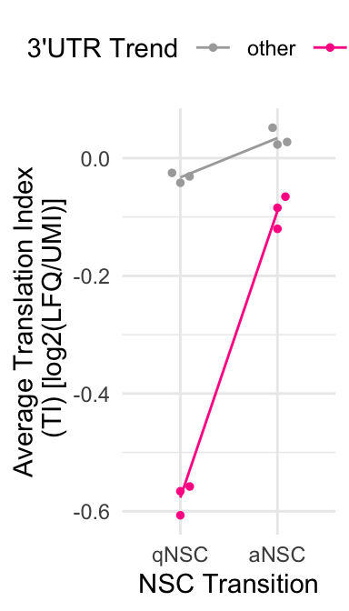

```r
# plot the interaction result
gg_trip <- ggplot(ti_tbl, aes(x = Cell_Type, y = TI, color = UTR, group = UTR )) + geom_beeswarm(cex = 5, size = 1) +
  theme_minimal() +
  stat_summary(fun = mean, geom="line") +
  labs(y = 'Average Translation Index\n (TI) [log2(LFQ/UMI)]',
       x = 'NSC Transition',
       color = "3'UTR Trend"
       ) +
  scale_color_manual(values = c('darkgrey', 'deeppink' )) +
  theme(legend.position = 'top')

gg_trip
```

In this plot every point (statisticla unit) is a replicate (mouse)

> CONCLUSION: Genes undergoing 3'UTR shortening from qNSCs to aNSCs also tend to have higher protein production in aNSCs vs. qNSCs

> INTERPRETATION: In NSCs, shortening of 3'UTRs correlates with higher mRNA translation efficiency.